# K-Means

Freddy Drennan

November 11, 2016

K-Means helps us label data. For example, I might have salary data for the company I work for. In order to describe this data, I might pick an arbitrary cutoff point to describe the data. For example, 100 people make less than 50,000 dollars; 50 people make between 50,000 and 100,000 dollars; and 10 make more than 100,000 dollars. However, K-Means can help us choose the cutoff points based on some unknown natural affinity or grouping that might be more meaningful than our chosen labels.

K-means allows us to choose a number of clusters that we which to describe. The k clusters are identified based on the data objects’ proximity to th center of the k groups. The center is the mean of each cluster’s n-dimensional attributes. Once we identify the clusters, we can label them. A practical use of the method would be to define your customer base and determine different groups of customers to target.

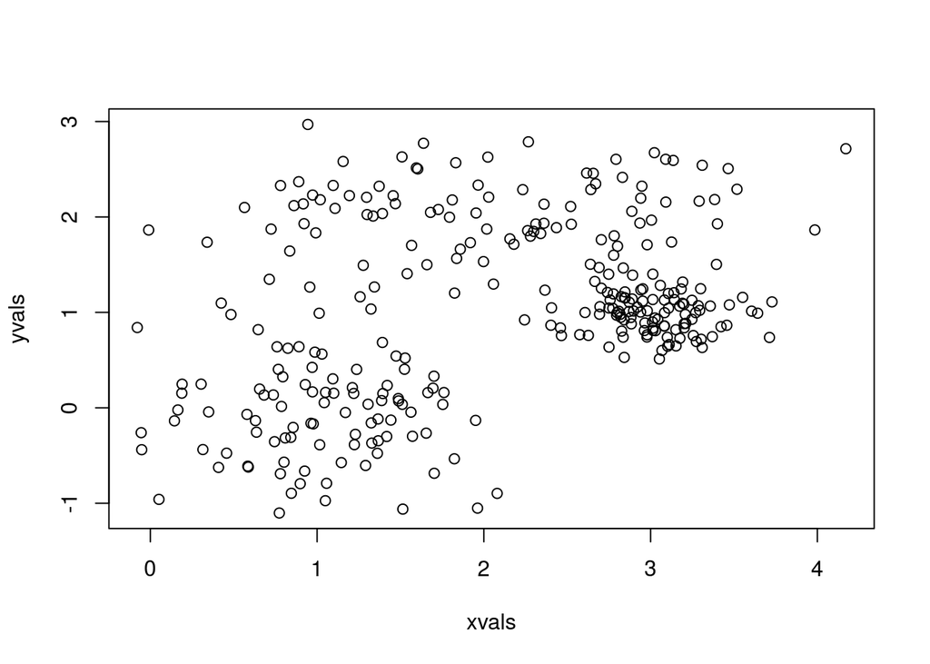

```r
distribution1x <- rnorm(100, mean = 2, sd = .8)
distribution1y <- rnorm(100, mean = 2, sd = .4)

distribution2x <- rnorm(100, mean = 1, sd = .5)
distribution2y <- rnorm(100, mean = 0, sd = .6)

distribution3x <- rnorm(100, mean =  3, sd = .3)
distribution3y <- rnorm(100, mean =  1, sd = .2)

val_df <- data.frame( xvals = c(distribution1x, distribution2x, distribution3x), yvals = c(distribution1y, distribution2y, distribution3y))

plot(val_df)
```

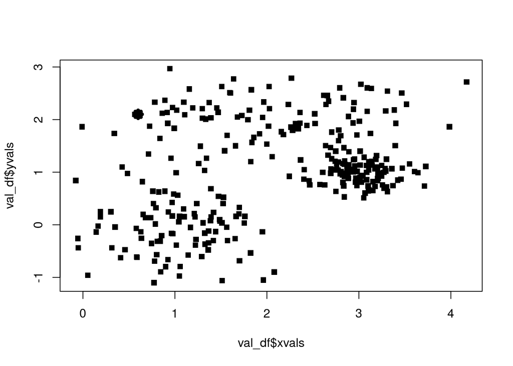

```r
guesses <- data.frame(xguess = c(.60, -.51, -.58), yguess = c(2.1, 1.9, 1.5))

plot(val_df$xvals, val_df$yvals, pch = 15)
points(guesses, col = c("black", "red", "purple"), pch =8, lwd = 5)
```

```r
centroidguesses <- data.frame(guesses)
```

2. We will compute the distance from each point $(x_i, y_i)$ to each entroid. We will then assign each point to the closest centroid. This association defines the first k clusters. In two dimensions, the distance, $d$, between any two points $(x_1, y_1)$ and $(x_2, y_2)$, is described by using the Euclidean distace formula shown below.

$$d = \sqrt{(x_1 - x_2)^2 + (y_1 - y_2)^2}$$

In the figure below, the points closest to a centroid are shaded.

We can use the *dist* function in R to calculate the distance between two points. A short example follows.

```r
point1 <- c(0, 1)
point2 <- c(1, 0)

# The code below is the same as sqrt((1-0)^2 + (0 - 1)^2)
dist(rbind(point1, point2))
```

```
##          point1
## point2 1.414214
```

```r
sqrt((1-0)^2 + (0 - 1)^2)
```

```
## [1] 1.414214
```

```r
head(val_df)
```

```
##      xvals    yvals
## 1 1.276691 1.493042
## 2 2.311705 1.926284
## 3 3.727724 1.109787
## 4 1.335551 2.009027
## 5 2.757144 1.129945
## 6 2.704079 1.761246
```

```r
head(guesses)
```

```
##   xguess yguess
## 1   0.60    2.1
## 2  -0.51    1.9
## 3  -0.58    1.5
```

```r
# Get eqclidean distance from each xval and yval to all centroids
for(i in 1:nrow(val_df)) {
  val_df$guess1dist[[i]] <- dist(rbind(c(val_df$xvals[i], val_df$yvals[i]), c(guesses$xguess[1], guesses$yguess[1])), method = "euclidean")
  val_df$guess2dist[[i]] <- dist(rbind(c(val_df$xvals[i], val_df$yvals[i]), c(guesses$xguess[2], guesses$yguess[2])), method = "euclidean")
  val_df$guess3dist[[i]] <- dist(rbind(c(val_df$xvals[i], val_df$yvals[i]), c(guesses$xguess[3], guesses$yguess[3])), method = "euclidean")
}

for(i in 1:nrow(val_df)) {
  val_df$guess1val[i] <- ifelse(val_df$guess1dist[i] == min(val_df$guess1dist[i], val_df$guess2dist[i], val_df$guess3dist[i]),
                                 1, 0)
   val_df$guess2val[i] <- ifelse(val_df$guess2dist[i] == min(val_df$guess1dist[i], val_df$guess2dist[i], val_df$guess3dist[i]),
                                 2, 0)
    val_df$guess3val[i] <- ifelse(val_df$guess3dist[i] == min(val_df$guess1dist[i], val_df$guess2dist[i], val_df$guess3dist[i]),
                                 3, 0)
}

head(val_df)
```

```
##      xvals    yvals guess1dist guess2dist guess3dist guess1val guess2val
## 1 1.276691 1.493042  0.9090151   1.832452   1.856704         1         0
## 2 2.311705 1.926284  1.7204973   2.821827   2.922957         1         0
## 3 3.727724 1.109787  3.2807283   4.310770   4.325361         1         0
## 4 1.335551 2.009027  0.7411553   1.848768   1.982030         1         0
## 5 2.757144 1.129945  2.3652219   3.356667   3.357599         1         0
## 6 2.704079 1.761246  2.1311735   3.217072   3.294453         1         0
##   guess3val
## 1         0
## 2         0
## 3         0
## 4         0
## 5         0
## 6         0
```

```r
tail(val_df)
```

```
##        xvals     yvals guess1dist guess2dist guess3dist guess1val
## 295 3.011204 0.8994215   2.693566   3.660606   3.641077         1
## 296 3.151190 0.8183177   2.855044   3.817636   3.792950         1
## 297 2.704399 1.2532123   2.268380   3.278826   3.293658         1
## 298 2.871949 1.1056184   2.480030   3.473992   3.474405         1
## 299 3.190843 1.0952358   2.778852   3.787332   3.792505         1
## 300 3.201594 0.8383137   2.891392   3.860455   3.839047         1
##     guess2val guess3val
## 295         0         0
## 296         0         0
## 297         0         0
## 298         0         0
## 299         0         0
## 300         0         0
```

```r
centroid1 <- subset(val_df, guess1val == 1)
centroid2 <- subset(val_df, guess2val == 2)
centroid3 <- subset(val_df, guess3val == 3)
```

Now we have three subsets of points, each closest to the origical centroids.

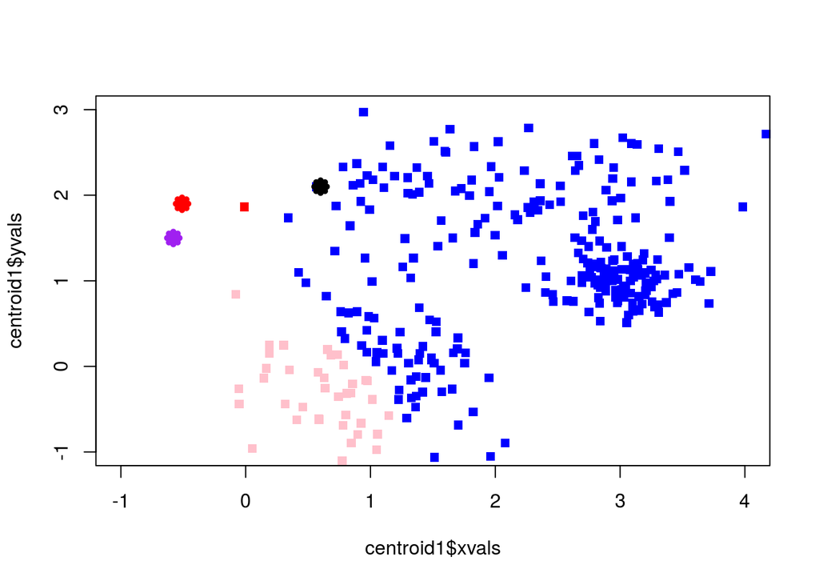

```r
plot(centroid1$xvals, centroid1$yvals, col = "blue", xlim = c(-1, 4), ylim = c(-1, 3), pch = 15)
points(centroid2$xvals, centroid2$yvals, col = "red",pch = 15)
points(centroid3$xvals, centroid3$yvals, col = "pink", pch =15)
points(guesses, col = c("black", "red", "purple"), pch =8, lwd = 5)
```

3. Next we’ll compute a new centroid based on the shaded points in each group.

$$(x_c, y_c) =\left \{ \frac{\sum_{i=1}^{m}{x_i}}{m} , \frac{\sum_{i=1}^{m}{y_i}}{m} \right \}$$

Here, $(x_c, y_c)$ is the ordered pair of the means of the coordinates of the m points in the cluster. In this step, a centroid is computed for each of the k clusters.

```r
centroid1new <- c(sum(centroid1$xvals)/length(centroid1$xvals), sum(centroid1$yvals/length(centroid1$yvals)))
centroid2new <- c(sum(centroid2$xvals)/length(centroid2$xvals), sum(centroid2$yvals/length(centroid2$yvals)))
centroid3new <- c(sum(centroid3$xvals)/length(centroid3$xvals), sum(centroid3$yvals/length(centroid3$yvals)))

guesses <- as.data.frame(rbind(centroid1new, centroid2new, centroid3new))
```

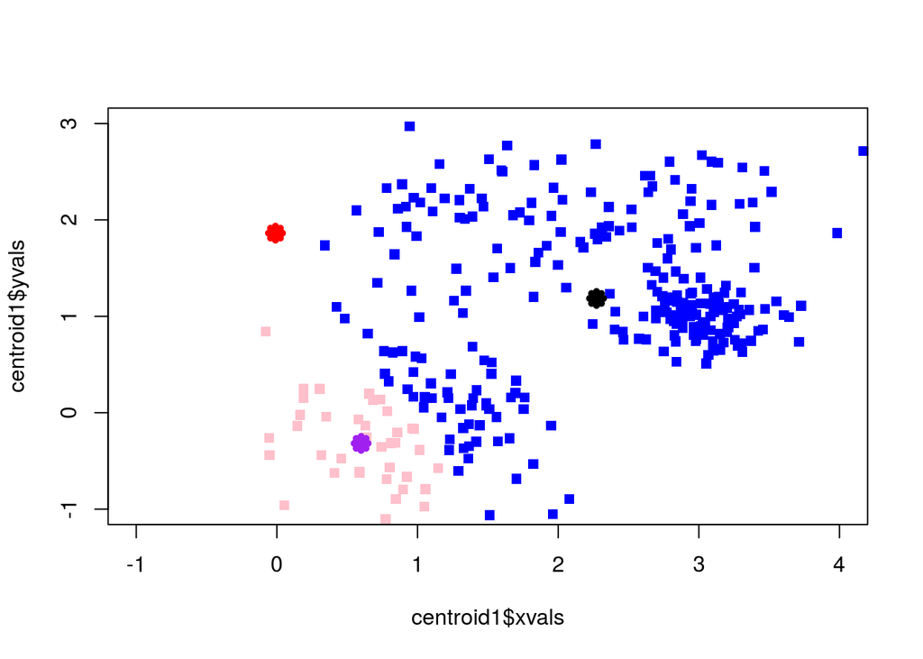

```r
colnames(guesses) <- c("xguess", "yguess")
centroidguesses <- rbind(centroidguesses, guesses)


plot(centroid1$xvals, centroid1$yvals, col = "blue",xlim = c(-1, 4), ylim = c(-1, 3), pch = 15)
points(centroid2$xvals, centroid2$yvals, col = "red", pch = 15)
points(centroid3$xvals, centroid3$yvals, col = "pink", pch = 15)
points(guesses, col = c("black", "red", "purple"), pch =8, lwd = 5)
```

Can you see how the centroids moved? Let’s interate this a few more times and see where these things go.

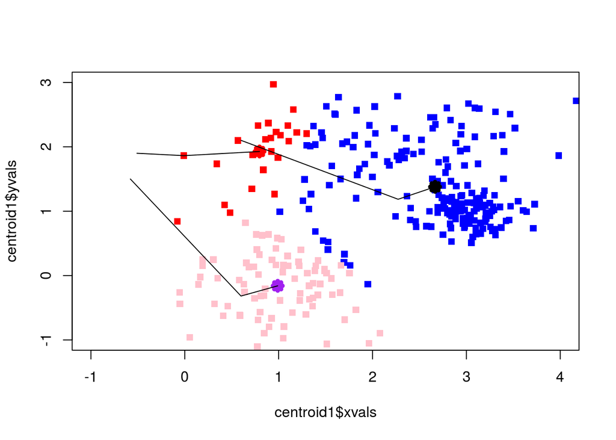

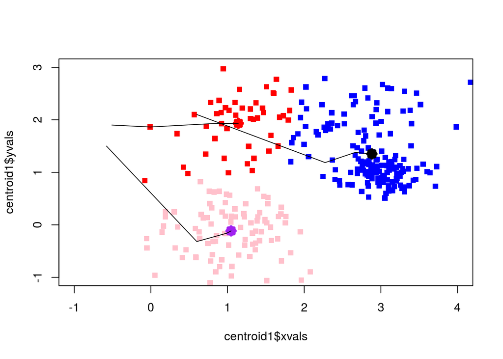

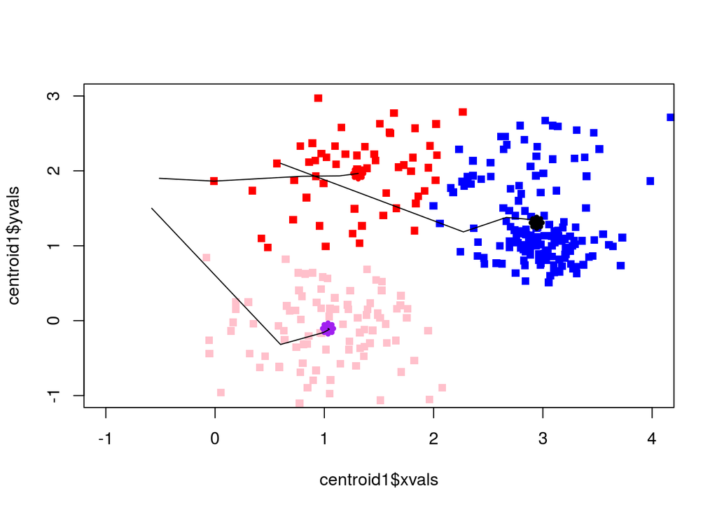

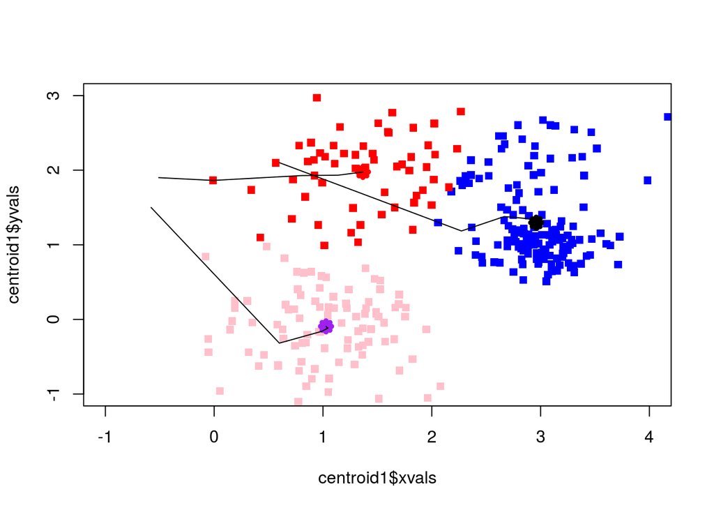

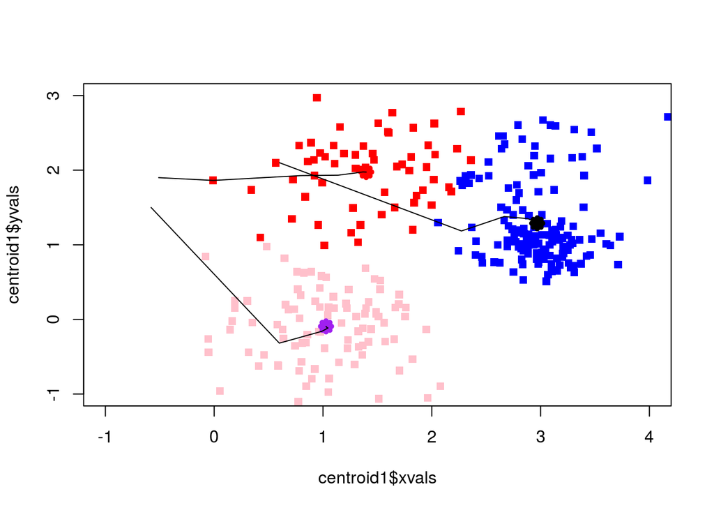

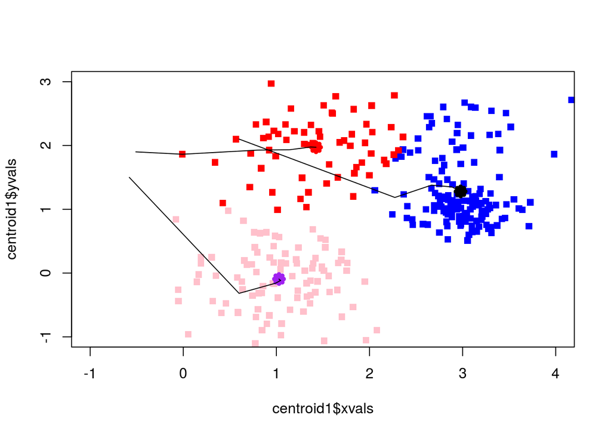

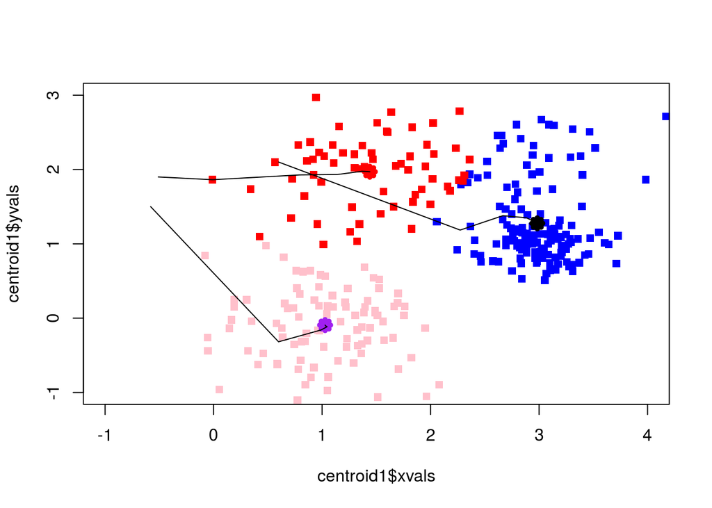

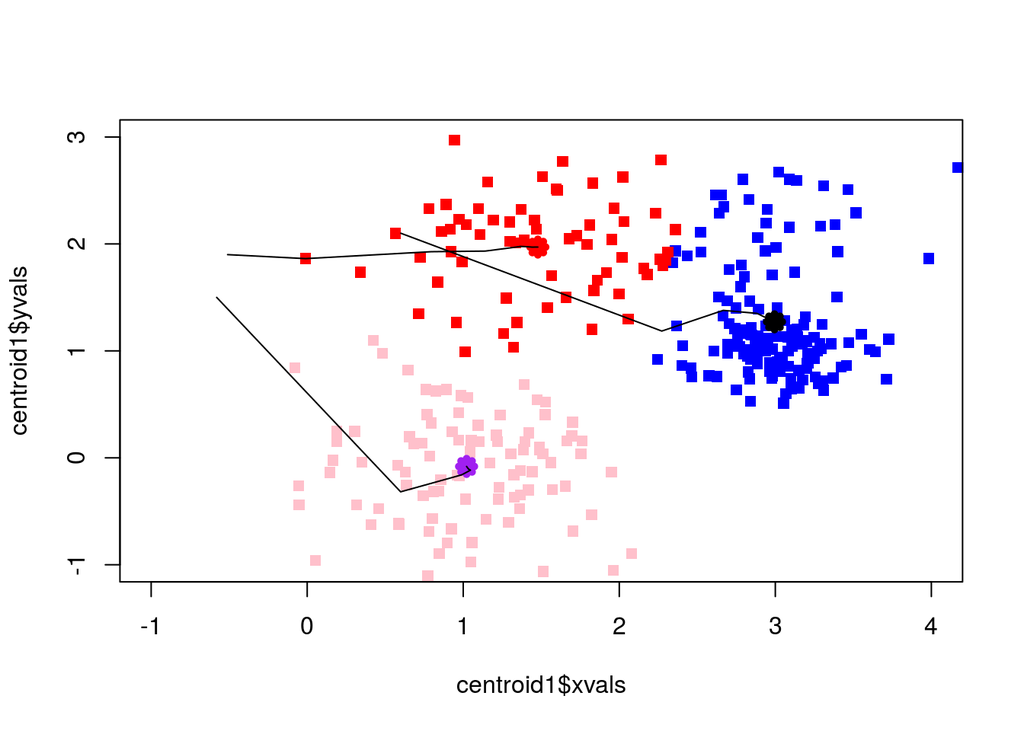

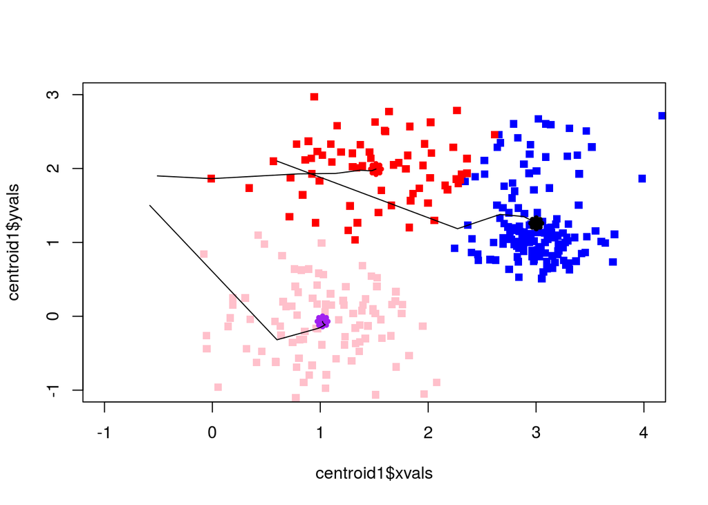

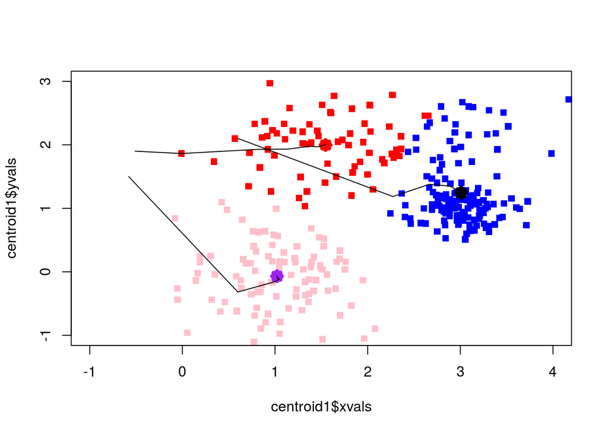

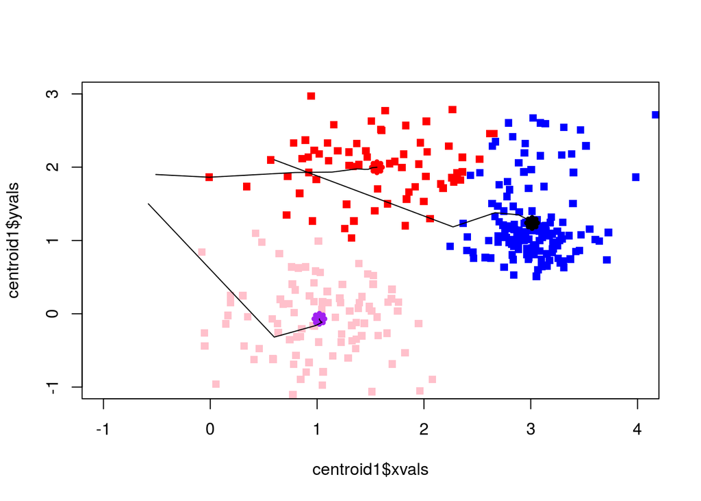

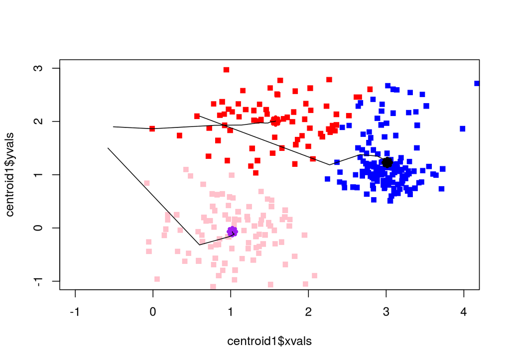

```r
for(iterations in 1:15) {
colnames(guesses) <- c("xguess", "yguess")
# Get eqclidean distance from each xval and yval to all centroids
for(i in 1:nrow(val_df)) {
  val_df$guess1dist[[i]] <- dist(rbind(c(val_df$xvals[i], val_df$yvals[i]), c(guesses$xguess[1], guesses$yguess[1])), method = "euclidean")
  val_df$guess2dist[[i]] <- dist(rbind(c(val_df$xvals[i], val_df$yvals[i]), c(guesses$xguess[2], guesses$yguess[2])), method = "euclidean")
  val_df$guess3dist[[i]] <- dist(rbind(c(val_df$xvals[i], val_df$yvals[i]), c(guesses$xguess[3], guesses$yguess[3])), method = "euclidean")
}

for(i in 1:nrow(val_df)) {
  val_df$guess1val[i] <- ifelse(val_df$guess1dist[i] == min(val_df$guess1dist[i], val_df$guess2dist[i], val_df$guess3dist[i]),
                                 1, 0)
   val_df$guess2val[i] <- ifelse(val_df$guess2dist[i] == min(val_df$guess1dist[i], val_df$guess2dist[i], val_df$guess3dist[i]),
                                 2, 0)
    val_df$guess3val[i] <- ifelse(val_df$guess3dist[i] == min(val_df$guess1dist[i], val_df$guess2dist[i], val_df$guess3dist[i]),
                                 3, 0)
}

centroid1 <- subset(val_df, guess1val == 1)
centroid2 <- subset(val_df, guess2val == 2)
centroid3 <- subset(val_df, guess3val == 3)

centroid1new <- c(sum(centroid1$xvals)/length(centroid1$xvals), sum(centroid1$yvals/length(centroid1$yvals)))
centroid2new <- c(sum(centroid2$xvals)/length(centroid2$xvals), sum(centroid2$yvals/length(centroid2$yvals)))
centroid3new<- c(sum(centroid3$xvals)/length(centroid3$xvals), sum(centroid3$yvals/length(centroid3$yvals)))

guesses <- as.data.frame(rbind(centroid1new, centroid2new, centroid3new))
colnames(guesses) <- c("xguess", "yguess")
centroidguesses <- rbind(centroidguesses, guesses)

plot(centroid1$xvals, centroid1$yvals, col = "blue", xlim = c(-1, 4), ylim = c(-1, 3), pch = 15)
points(centroid2$xvals, centroid2$yvals, col = "red", pch = 15)
points(centroid3$xvals, centroid3$yvals, col = "pink", pch = 15)
points(guesses, col = c("black", "red", "purple"), pch =8, lwd = 5)
points(centroidguesses[seq(1, nrow(centroid1), by = 3),], type = "l")
points(centroidguesses[seq(2, nrow(centroid1), by = 3),], type = "l")
points(centroidguesses[seq(3, nrow(centroid1), by = 3),], type = "l")
}
```

[output not shown]

Could I have saved a lot of time doing what I did above? Why yes, everything that I’ve written above can be summed up and more with the following one line of code:

```r
km <- kmeans(val_df, centers = 3, nstart = 25)
km
```

```
## K-means clustering with 3 clusters of sizes 72, 95, 133
##
## Cluster means:
##      xvals       yvals guess1dist guess2dist guess3dist guess1val
## 1 1.619669  2.01457202  1.7029806  0.6817088  2.2479309         0
## 2 1.021283 -0.06936036  2.4298744  2.2266200  0.6268611         0
## 3 3.024083  1.20823727  0.4935711  1.6976441  2.4104077         1
##   guess2val guess3val
## 1         2         0
## 2         0         3
## 3         0         0
##
## Clustering vector:
##   [1] 1 1 3 1 3 3 3 1 1 3 3 1 1 1 3 1 1 3 1 3 1 1 1 1 3 3 3 3 1 1 1 1 3 1 1
##  [36] 1 1 1 3 1 1 1 3 1 3 3 1 1 3 3 3 1 3 1 1 1 1 3 1 1 1 3 1 3 1 1 1 1 1 1
##  [71] 1 1 1 1 1 3 3 1 1 1 1 1 1 1 3 1 1 1 3 3 3 1 1 1 1 1 1 3 3 1 2 2 2 2 2
## [106] 2 2 2 2 2 2 2 2 2 2 2 2 2 2 2 2 2 2 2 2 2 2 2 2 2 2 2 2 2 2 2 2 2 2 2
## [141] 2 2 2 2 2 1 2 2 2 2 2 2 2 2 1 2 2 1 2 2 2 2 2 2 2 2 2 1 2 2 2 2 2 1 2
## [176] 2 2 2 2 2 2 2 2 2 2 2 2 2 2 2 2 2 2 2 2 2 2 2 2 2 3 3 3 3 3 3 3 3 3 3
## [211] 3 3 3 3 3 3 3 3 3 3 3 3 3 3 3 3 3 3 3 3 3 3 3 3 3 3 3 3 3 3 3 3 3 3 3
## [246] 3 3 3 3 3 3 3 3 3 3 3 3 3 3 3 3 3 3 3 3 3 3 3 3 3 3 3 3 3 3 3 3 3 3 3
## [281] 3 3 3 3 3 3 3 3 3 3 3 3 3 3 3 3 3 3 3 3
##
## Within cluster sum of squares by cluster:
## [1] 81.72067 97.69271 98.46552
##  (between_SS / total_SS =  86.7 %)
##
## Available components:
##
## [1] "cluster"      "centers"      "totss"        "withinss"
## [5] "tot.withinss" "betweenss"    "size"         "iter"
## [9] "ifault"
```

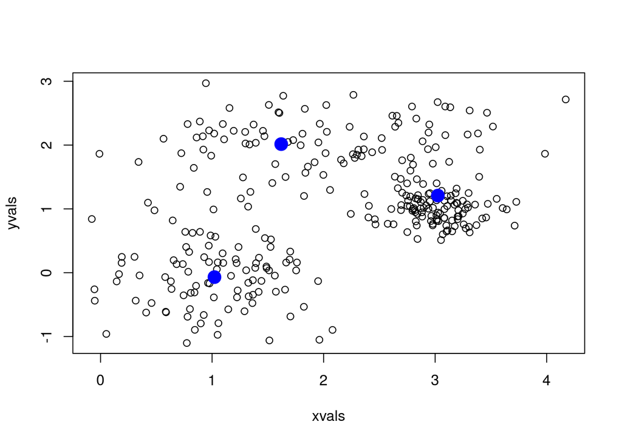

```r
plot(val_df[,1:2])
points(km$centers, pch = 20, col = "blue", lwd = 10)
```

Let’s do this in real life now. The following example comes from *Data Science and Big Data Analytics* by EMC Education Services.

```r
library(plyr)
library(ggplot2)
library(cluster)
library(lattice)
library(graphics)
library(grid)
library(gridExtra)

grade_input <- read.csv("/home/fdrennan/Documents/r/practicalDataScience/DSBDA_code_data/Chapter4/grades_km_input.csv")
summary(grade_input)
```

```
##     Student         English           Math           Science
##  Min.   :  1.0   Min.   : 56.0   Min.   : 55.00   Min.   : 55.0
##  1st Qu.:155.8   1st Qu.: 78.0   1st Qu.: 69.00   1st Qu.: 70.0
##  Median :310.5   Median : 85.0   Median : 78.00   Median : 80.0
##  Mean   :310.5   Mean   : 84.3   Mean   : 77.88   Mean   : 79.4
##  3rd Qu.:465.2   3rd Qu.: 95.0   3rd Qu.: 85.25   3rd Qu.: 90.0
##  Max.   :619.0   Max.   :100.0   Max.   :100.00   Max.   :100.0
```

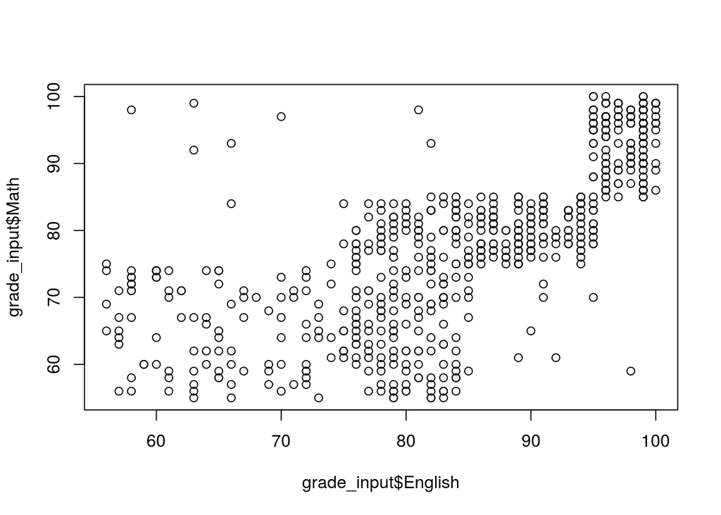

```r
plot(grade_input$English, grade_input$Math)
```

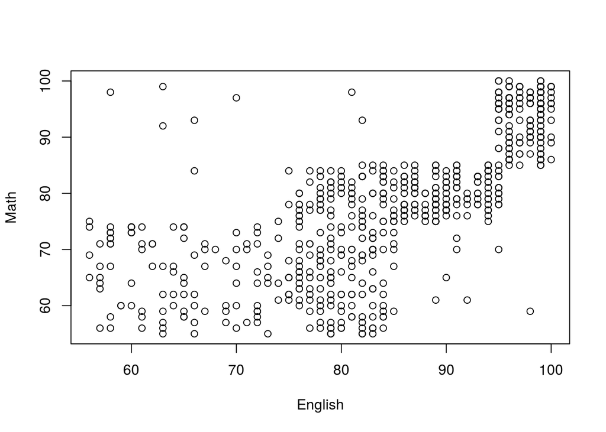

```r
kmdata_orig <- as.matrix(grade_input[,c("Student", "English", "Math", "Science")])
kmdata <- kmdata_orig[,2:4]
plot(kmdata)
```

Let’s look at how the WSS changes as we add clusters

```r
wss <- numeric(15)
wss
```

```
##  [1] 0 0 0 0 0 0 0 0 0 0 0 0 0 0 0
```

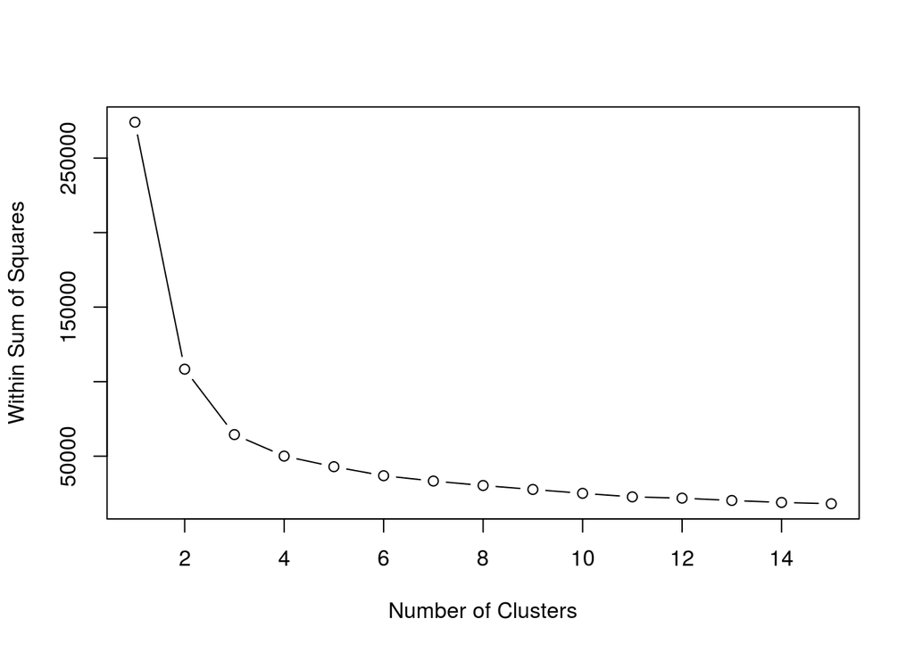

```r
for(k in 1:15) wss[k] <- sum(kmeans(kmdata, centers = k, nstart=25)$withinss)
plot(1:15, wss, type = "b", xlab = "Number of Clusters", ylab = "Within Sum of Squares")
```

```r
km = kmeans(kmdata, 3, nstart = 25)

# Check that the solution is a good one
c(wss[3], sum(km$withinss))
```

```
## [1] 64483.06 64483.06
```

Next, let’s preparte the data for clustering and plotting

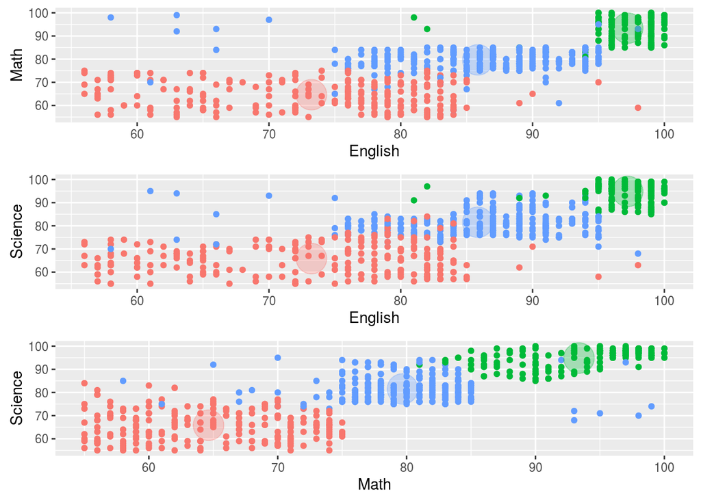

```r
df = as.data.frame(kmdata_orig[,2:4])
df$cluster = factor(km$cluster)
centers = as.data.frame(km$centers)

g1 <- ggplot(data=df, aes(x=English, y=Math, color=cluster)) +
  geom_point() + theme(legend.position="right") +
  geom_point(data = centers,
             aes(x=English, y=Math, color=as.factor(c(1,2,3))),
             size=10, alpha=.3)

g2 <- ggplot(data=df, aes(x=English, y=Science, color=cluster)) +
  geom_point() +
  geom_point(data = centers,
             aes(x=English, y=Science, color=as.factor(c(1,2,3))),
             size=10, alpha=.3)


g3 <- ggplot(data=df, aes(x=Math, y=Science, color=cluster)) +
  geom_point() + theme(legend.position="right") +
  geom_point(data = centers,
             aes(x=Math, y=Science, color=as.factor(c(1,2,3))),
             size=10, alpha=.3)

tmp <- ggplot_gtable(ggplot_build(g1))

grid.arrange(arrangeGrob(g1 + theme(legend.position="none"),
                         g2 + theme(legend.position="none"),
                         g3 + theme(legend.position="none")))
```

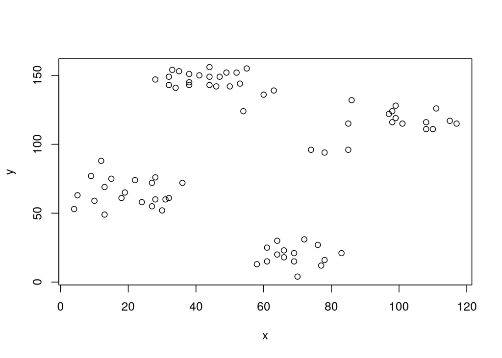

```r
data(ruspini)
plot(ruspini)
```

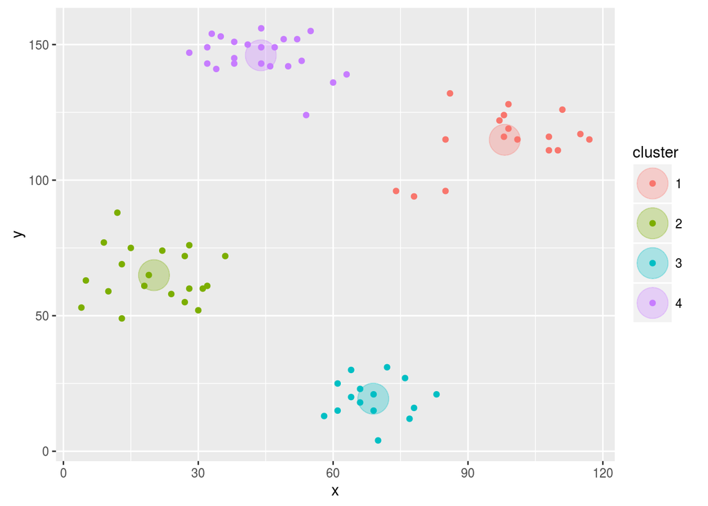

```r
kmrus <- kmeans(ruspini, centers=4, nstart = 25)
ruspini$cluster <- factor(kmrus$cluster)
centers <- as.data.frame(kmrus$centers)


g1 <- ggplot(data=ruspini, aes(x=x, y=y, color=cluster)) +
  geom_point() + theme(legend.position="right") +
  geom_point(data = centers,
             aes(x=x, y=y, color=as.factor(c(1,2, 3, 4))),
             size=10, alpha=.3)
g1
```